# Homework 9

Tate Andrew Keller

3/12/2020

# Problem 1

The github repository was created at https://github.com/tatkeller/ANGSD_final_project.

# Problem 2

## Indexing

I began by indexing the human genome 38, with the following script.

```bash
#! /bin/bash

spack load star@2.7.0e

mkdir -p /scratchLocal/tak76

STAR --runMode genomeGenerate \
     --runThreadN 1 \
     --genomeDir  /home/tak76/tak76/finalProject/hg38index \
     --genomeFastaFiles /home/tak76/tak76/finalProject/hg38/hg38.fa \
     --sjdbGTFfile  /home/tak76/tak76/finalProject/hg38/hg38.refGene.gtf \
     --sjdbOverhang 124 \
     --outTmpDir /scratchLocal/tak76/hg38_genome

rm -rf /scratchLocal/tak76
```

## Alignment

I created an alignment script, which uses a for loop to call STAR on each sample. The samples for the human genome are very large, so I began with 3 samples. The combined time of indexing and aligning took around ~12 hours.

```bash
#!/bin/bash

spack load star@2.7.0e

FILES="SRR4888615
SRR4888616
SRR4888618"

for file in $FILES; do
 STAR --runMode alignReads \
      --runThreadN 4 \
      --genomeDir /home/tak76/tak76/finalProject/hg38index \
      --readFilesIn /home/tak76/tak76/finalProject/fastq/${file}/* \
      --readFilesCommand zcat \
      --outFileNamePrefix /home/tak76/tak76/finalProject/alignments/${file}. \
      --outFilterMultimapNmax 1 \
      --outSAMtype BAM SortedByCoordinate \
      --twopassMode Basic \
      --alignIntronMin 1 \
      --alignIntronMax 3000
done
```

# Problem 3

## Read Counts

Finally, I made a script to call feature counts on the samples that I aligned.

```bash
#! /bin/bash

spack load subread

featureCounts -a /home/tak76/tak76/finalProject/hg38/hg38.refGene.gtf \
              -o featureCounts.txt\
              /home/tak76/tak76/finalProject/alignments/*.bam
```

# Problem 4

I read the read counts summary into R, and first created a bar chart of the 3 samples and their distrubtion of assigned to unassigned reads. The distribution shows that each sample has a majority of reas unassigned (no feature). SRR4888616 and SRR4888618 have around the same amount of assigned reads.

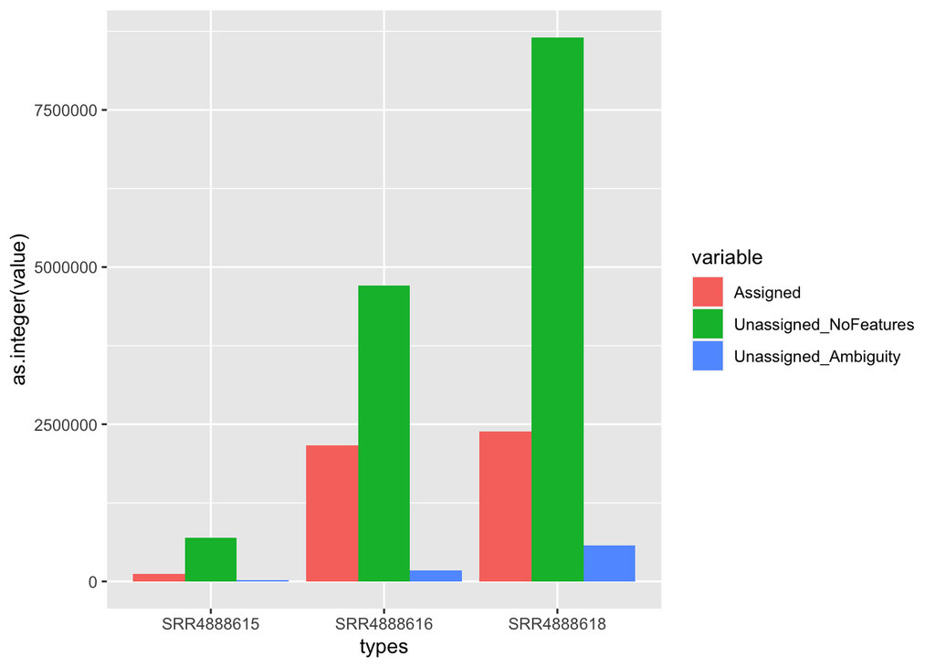

```r
library(magrittr)
library(data.table)
library(ggplot2)
library(reshape2)
genes <- data.table::fread(file = 'featureCounts.txt.summary', header = TRUE)%>% as.data.frame

names(genes) <- c('Status', 'SRR4888615','SRR4888616','SRR4888618')

assigned = genes[genes$Status == 'Assigned',]
unassigned_nofeatures = genes[genes$Status == 'Unassigned_NoFeatures',]
unassigned_ambiguity = genes[genes$Status == 'Unassigned_Ambiguity',]

df = rbind(assigned,unassigned_nofeatures,unassigned_ambiguity)

df = transpose(df)
names(df) <- df[1,]
df <- df[-1,]

df$types = c('SRR4888615','SRR4888616','SRR4888618')

dfm <- melt(df[,c('types','Assigned','Unassigned_NoFeatures','Unassigned_Ambiguity')],id.vars = 1)

ggplot(data = dfm, aes(x = types, y = as.integer(value), fill = variable)) + geom_bar(stat='identity', position='dodge')
```

Next I read in the full read counts file into R. I performed some normalization measures and plotted some results.

```r
readcounts <- read.table("featureCounts.txt", header=TRUE)
orig_names <- names(readcounts)

#Change file names to sample names
names(readcounts)[7:9] = c('SRR4888615','SRR4888616','SRR4888618')

library(DESeq2)
row.names(readcounts) <- make.names(readcounts$Geneid)
readcounts <- readcounts[ , -c(1:6)]

sample_info <- DataFrame(condition = gsub("_[0-9]+", "", names(readcounts)),row.names = names(readcounts) )

DESeq.ds <- DESeqDataSetFromMatrix(countData = readcounts,colData = sample_info,design = ~ condition)
#Sum the counts for each Gene per sample
colSums(counts(DESeq.ds))
```

```
## SRR4888615 SRR4888616 SRR4888618
##     116147    2167074    2389609
```

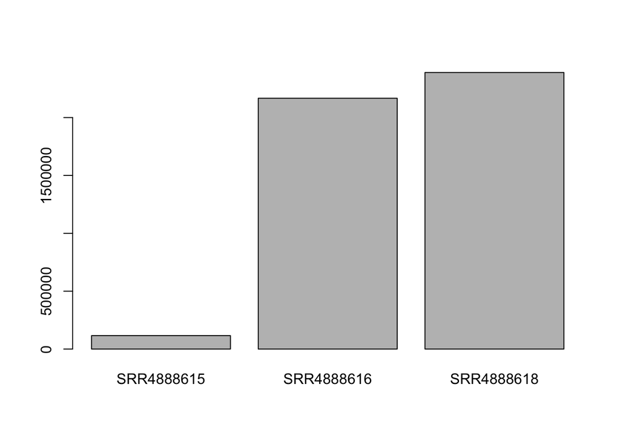

```r
colSums(counts(DESeq.ds)) %>% barplot
```

```r
#Plot the counts, as comparison
keep_genes <- rowSums(counts(DESeq.ds)) > 0
DESeq.ds <- DESeq.ds[ keep_genes, ]
```

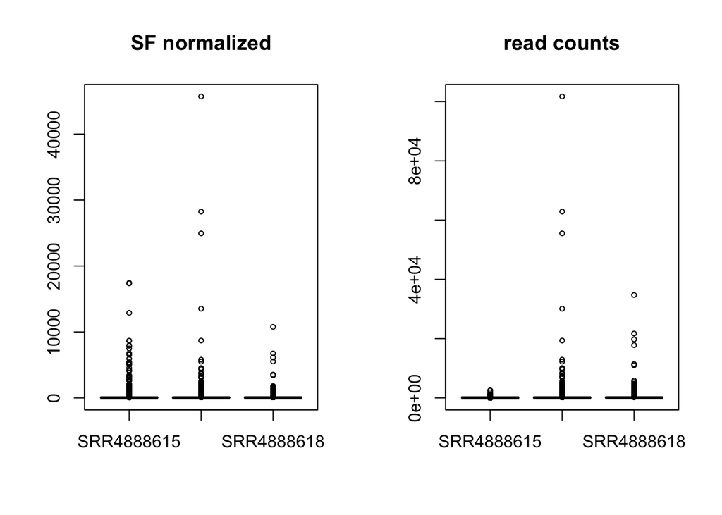

```r
par(mfrow=c(1,2))
DESeq.ds <- estimateSizeFactors(DESeq.ds)

#Normalize the size factors of the samples
counts.sf_normalized <- counts(DESeq.ds, normalized=TRUE)

#Compare the normalized size factors to the read counts
boxplot(counts.sf_normalized, main = "SF normalized", cex = .6)
boxplot(counts(DESeq.ds), main = "read counts", cex = .6)
```

The ranges significantly decrease with the size factors normalized.

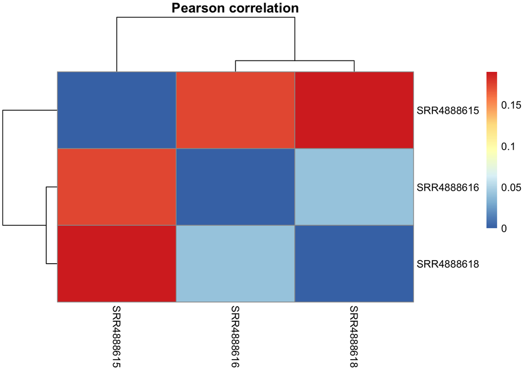

```r
DESeq.rlog <- rlog(DESeq.ds, blind = TRUE)
rlog.norm.counts <- assay(DESeq.rlog)

corr_coeff <- cor(rlog.norm.counts, method = "pearson")

as.dist(1-corr_coeff, upper = TRUE) %>% as.matrix %>% pheatmap::pheatmap(., main = "Pearson correlation")
```

SRR4888618 and SRR4888616 correlate much closer to one another than they do to SRR4888615.

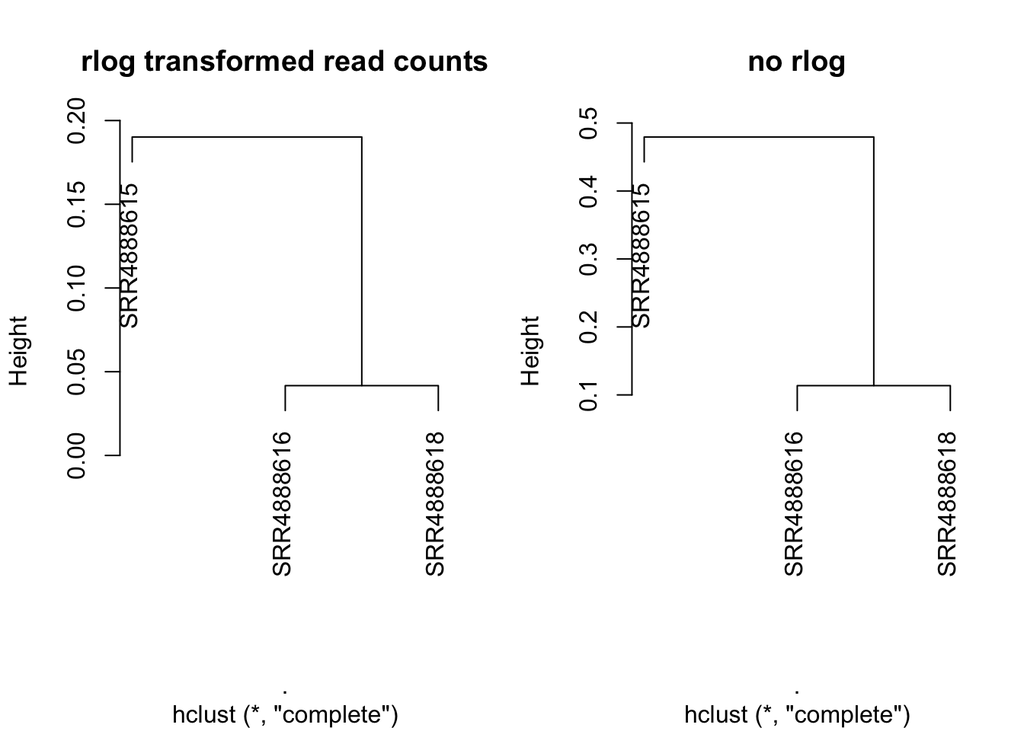

```r
par(mfrow=c(1,2))

log.counts <- log2(counts(DESeq.ds, normalized = FALSE) + 1)
assay(DESeq.ds, "log.counts") <- log2(counts(DESeq.ds, normalized = FALSE) + 1)
log.norm.counts <- log2(counts(DESeq.ds, normalized=TRUE) + 1)
assay(DESeq.ds, "log.norm.counts") <- log.norm.counts

as.dist(1 - corr_coeff) %>% hclust %>% plot( ., labels = colnames(rlog.norm.counts), main = "rlog transformed read counts")

as.dist( 1 - cor(log.norm.counts, method = "pearson")) %>% hclust %>% plot( ., labels = colnames(log.norm.counts), main = "no rlog")
```

The correlation can be shown through a dendrogram, which will be more telling with an increase in the number of samples.

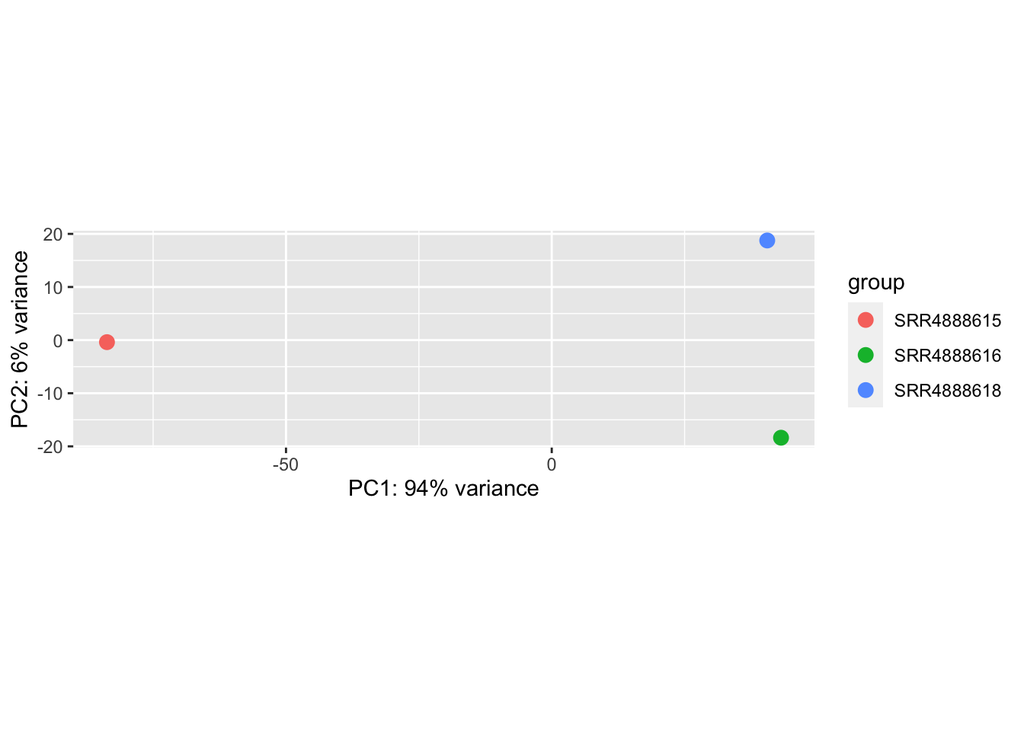

```r
rv <- rowVars(assay(DESeq.rlog))
top_variable <- order(rv, decreasing = TRUE)[seq_len(500)]
pca <- prcomp(t(assay(DESeq.rlog)[top_variable, ]))
plotPCA(DESeq.rlog)
```

Finally, a principal compnents analysis graph shows again how SRR4888618 and SRR4888616 are more similar to eachother than to SRR4888615, though the second principcal component identifies differences between SRR4888618 and SRR4888616 as well. Additional samples will need to be aligned over time in order to understand more of what is happening here.